# HW 5

Mykola Chuprinskiy

2024-10-17

The Macroeconomic variables, both real and financial, do have considerable influence, positive as well as negative, on the performance of the corporate sector of the economy. Consequently, the stock markets of the economy got affected by such performance. The movement of stock prices, apart from the firms’ fundamentals, also depends upon the level of development achieved in the economy and its integration towards the world economy. Since macroeconomic variables are highly interdependent, using all of them as explana- tory variables in affecting the stock market may pose a severe multicolinearity problem and it becomes difficult to delineate the separate affects of different variables on the stock mar- ket movement. Deriving basic factors from such macroeconomic variables and employing these factors in pricing models can provide valuable information about the contents of priced factors in different stock markets. Generating orthogonal factor realizations elimi- nates the multicolinearity problem in estimating factor regression coefficients and serves to find the factors that are rewarded by the market. In this assignment, such factors will be extracted from twelve macroeconomic variables in India. The variables are: 1. Money Supply (MS), 2. Consumer Price Index (CPI), 3. Gold Prices (GP), 4. Crude Oil Prices (COP), 5. Foreign Exchange Reserves (FER), 6. Foreign Direct Investment (FDI), 7. Foreign Institutional Investment (FII), 8. Call Money Rate (CMR), 9. Balance of Trade (BOT), 10. Foreign Exchange Rate (ER), 11. Repo Rate (Repo), 12. Industrial Growth Rate (IGR). The standardized observations in the data file IndianSM.txt are based on monthly aver- ages, for 149 months.

```r
library(psych)
library(e1071)
library(fastICA)

IndianSM <- read.table("IndianSM.txt", header=TRUE)
```

1. Factor analyze the data and determine how many common factors are at least needed to explain at least 80% of the total variance.

```r
IndianSM_standardized <- scale(IndianSM)

fa_analysis <- fa(IndianSM_standardized, nfactors=12, rotate="none")

print(fa_analysis$Vaccounted)
```

```
                            MR1       MR2       MR3        MR4        MR5
SS loadings           6.4973254 2.0918528 1.4716211 0.42129871 0.16665511
Proportion Var        0.5414438 0.1743211 0.1226351 0.03510823 0.01388793
Cumulative Var        0.5414438 0.7157649 0.8383999 0.87350817 0.88739610
Proportion Explained  0.5940382 0.1912541 0.1345475 0.03851854 0.01523696
Cumulative Proportion 0.5940382 0.7852923 0.9198398 0.95835838 0.97359534
                              MR6         MR7         MR8         MR9
SS loadings           0.099823954 0.078809480 0.059312415 0.028987149
Proportion Var        0.008318663 0.006567457 0.004942701 0.002415596
Cumulative Var        0.895714762 0.902282219 0.907224920 0.909640516
Proportion Explained  0.009126715 0.007205402 0.005422822 0.002650240
Cumulative Proportion 0.982722056 0.989927458 0.995350280 0.998000520
                             MR10         MR11         MR12
SS loadings           0.013401630 0.0084677975 1.200000e-29
Proportion Var        0.001116802 0.0007056498 1.000000e-30
Cumulative Var        0.910757318 0.9114629680 9.114630e-01
Proportion Explained  0.001225286 0.0007741947 1.097137e-30
Cumulative Proportion 0.999225805 1.0000000000 1.000000e+00
```

2. Does the factor model with the in (a) selected number of common factors fit to the data? Why?

```r
#nfactors = 3 bcs 3 are enough to explain 80%

fa_selected <- fa(IndianSM_standardized, nfactors=3, rotate="varimax")
print(fa_selected)
```

```
Factor Analysis using method =  minres
Call: fa(r = IndianSM_standardized, nfactors = 3, rotate = "varimax")
Standardized loadings (pattern matrix) based upon correlation matrix
       MR1   MR2   MR3   h2     u2 com
MS    0.94  0.32  0.00 0.99 0.0091 1.2
CPI   0.92  0.35  0.02 0.98 0.0237 1.3
GP    0.90  0.40  0.09 0.97 0.0305 1.4
COP   0.94 -0.15  0.15 0.92 0.0779 1.1
FER   0.97  0.05 -0.07 0.94 0.0559 1.0
FDI   0.65 -0.26  0.10 0.50 0.4997 1.4
FII   0.59  0.00 -0.20 0.39 0.6111 1.2
CMR   0.30  0.15  0.92 0.96 0.0391 1.3
BOT  -0.87 -0.31 -0.16 0.87 0.1262 1.3
ER    0.16  0.96  0.15 0.96 0.0366 1.1
Repo -0.19  0.08  0.83 0.73 0.2695 1.1
IGR  -0.04 -0.75 -0.06 0.56 0.4390 1.0

                       MR1  MR2  MR3
SS loadings           6.04 2.07 1.68
Proportion Var        0.50 0.17 0.14
Cumulative Var        0.50 0.68 0.82
Proportion Explained  0.62 0.21 0.17
Cumulative Proportion 0.62 0.83 1.00

Mean item complexity =  1.2
Test of the hypothesis that 3 factors are sufficient.

df null model =  66  with the objective function =  18.9 with Chi Square =  2705.5
df of  the model are 33  and the objective function was  1.59

The root mean square of the residuals (RMSR) is  0.03
The df corrected root mean square of the residuals is  0.04

The harmonic n.obs is  149 with the empirical chi square  13.38  with prob <  1
The total n.obs was  149  with Likelihood Chi Square =  225.06  with prob <  1.9e-30

Tucker Lewis Index of factoring reliability =  0.852
RMSEA index =  0.198  and the 90 % confidence intervals are  0.174 0.223
BIC =  59.93
Fit based upon off diagonal values = 1
Measures of factor score adequacy
                                                   MR1  MR2  MR3
Correlation of (regression) scores with factors   1.00 0.99 0.99
Multiple R square of scores with factors          1.00 0.98 0.99
Minimum correlation of possible factor scores     0.99 0.96 0.97
```

```r
cat("Goodness of Fit for 3 factors model:\n")
```

```
Goodness of Fit for 3 factors model:
```

```r
print(fa_selected$STATISTIC)
```

```
[1] 225.0578
```

3. Give the correlations between the ‘regression’ factor scores, given the in (a) selected number of common factors.

```r
fa_factanal <- factanal(IndianSM_standardized, factors = 3, scores = "regression")
cor(fa_factanal$scores)
```

```
             Factor1    Factor2      Factor3
Factor1  1.000000000 0.02534665 -0.002031443
Factor2  0.025346648 1.00000000  0.013662242
Factor3 -0.002031443 0.01366224  1.000000000
```

4. Carry out an independent component analysis and determine the number of inde- pendent components. How many independent components do you select? Why?

```r
ica_result <- fastICA(IndianSM_standardized, n.comp=12, maxit=1000, tol=0.0001)

print(ica_result$S)
```

[output not shown]

[output cut: 435 more lines]

```r
cov_ica <- cov(ica_result$S)

eigenvalues <- eigen(cov_ica)$values
print(eigenvalues)
```

```
 [1] 1.006757 1.006757 1.006757 1.006757 1.006757 1.006757 1.006757 1.006757
 [9] 1.006757 1.006757 1.006757 1.006757
```

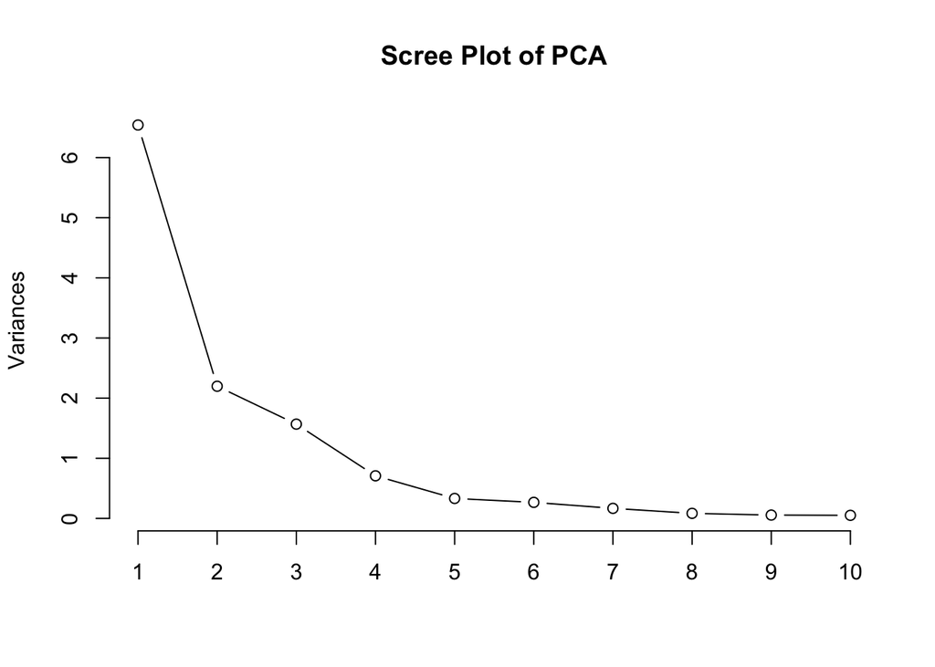

Figure

```r
IndianSM_pca <- prcomp(IndianSM_standardized, center = TRUE, scale. = TRUE)
screeplot(IndianSM_pca, type = "lines", main = "Scree Plot of PCA")
```

5. Give the correlations between the features (macro-economic variables) and the in- dependent components. Use these correlations to interpret the independent compo- nents.

```r
ica_result <- fastICA(IndianSM_standardized, n.comp=3, maxit=1000, tol=0.0001)

cor_ica <- cor(IndianSM, ica_result$S)
print(cor_ica)
```

```
           [,1]        [,2]       [,3]
MS    0.9263076  0.07781317  0.3336758
CPI   0.9314049  0.09686142  0.2986280
GP    0.9539200  0.08369508  0.2145046
COP   0.7597027 -0.34091159  0.4667440
FER   0.8082624 -0.05633645  0.5275004
FDI   0.4726104 -0.46045167  0.4656924
FII   0.4478051  0.09417439  0.5527551
CMR   0.6013956 -0.53858173 -0.5131286
BOT  -0.9251771  0.01933439 -0.1983136
ER    0.6217701  0.52367379 -0.4803989
Repo  0.1554481 -0.54048604 -0.7584277
IGR  -0.4489873 -0.60840846  0.4740320
```

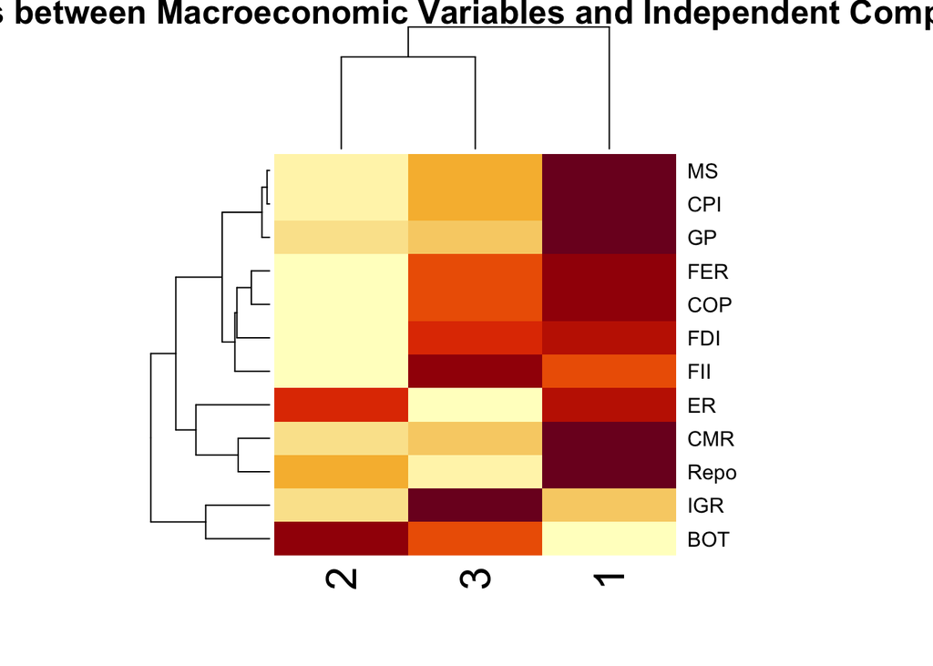

Figure

```r
cor_factors_selected <- cor(IndianSM, fa_selected$scores)
cor_factors_factanal <- cor(IndianSM, fa_factanal$scores)

heatmap(cor_ica, main="Correlations between Macroeconomic Variables and Independent Components (ICA)")
```

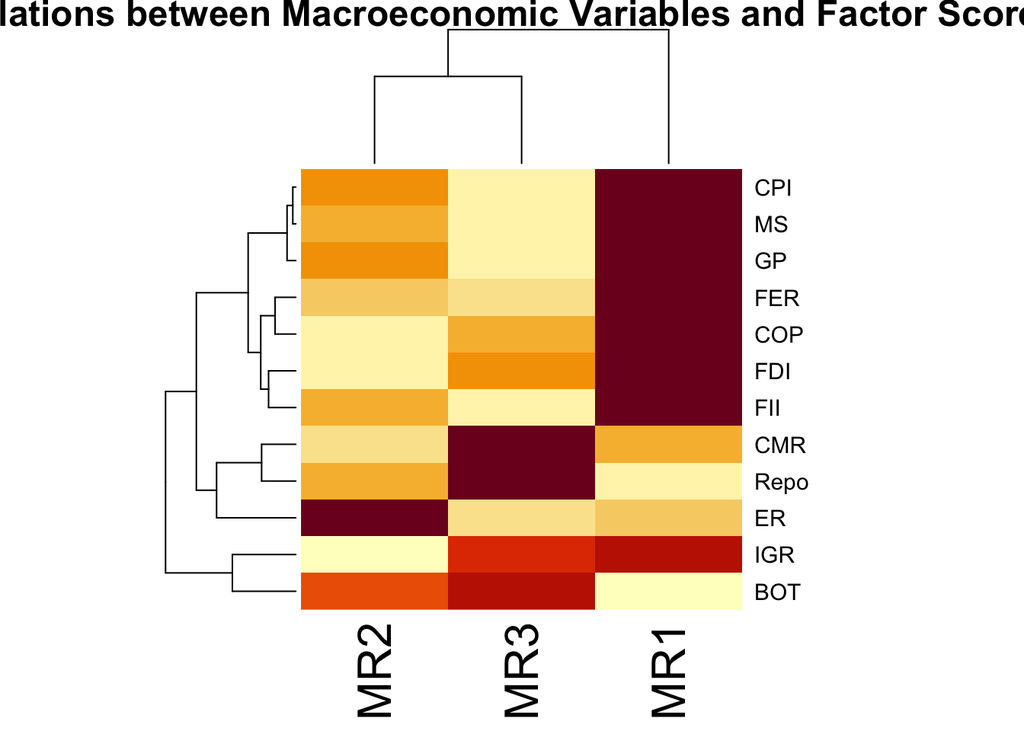

Figure

```r
heatmap(cor_factors_selected, main="Correlations between Macroeconomic Variables and Factor Scores (FA)")
```

```r
cor_ICA <- cor(IndianSM, ica_result$scores)
cor_ICA
```

```
             MS        CPI          GP         COP        FER        FDI
MS    1.0000000  0.9888940  0.98024799  0.83285152  0.9226636  0.5362001
CPI   0.9888940  1.0000000  0.97808081  0.80765730  0.8942560  0.4986733
GP    0.9802480  0.9780808  1.00000000  0.79629299  0.8683028  0.4832903
COP   0.8328515  0.8076573  0.79629299  1.00000000  0.8875360  0.6713180
FER   0.9226636  0.8942560  0.86830283  0.88753596  1.0000000  0.6789625
FDI   0.5362001  0.4986733  0.48329035  0.67131802  0.6789625  1.0000000
FII   0.5583527  0.5677897  0.51677532  0.52899607  0.5739742  0.2519094
CMR   0.3472246  0.3624183  0.43109714  0.38524448  0.2339362  0.2648656
BOT  -0.9058835 -0.9069318 -0.90462670 -0.79623129 -0.8318498 -0.4929881
ER    0.4470206  0.4885929  0.52645050  0.03458347  0.2075501 -0.1217815
Repo -0.1635559 -0.1420848 -0.07828262 -0.04682005 -0.2514572 -0.1047303
IGR  -0.2874314 -0.2946030 -0.35047206  0.05697930 -0.1153878  0.1531875
             FII         CMR         BOT          ER        Repo         IGR
MS    0.55835267  0.34722457 -0.90588351  0.44702062 -0.16355586 -0.28743142
CPI   0.56778965  0.36241835 -0.90693177  0.48859286 -0.14208484 -0.29460302
GP    0.51677532  0.43109714 -0.90462670  0.52645050 -0.07828262 -0.35047206
COP   0.52899607  0.38524448 -0.79623129  0.03458347 -0.04682005  0.05697930
FER   0.57397421  0.23393615 -0.83184984  0.20755015 -0.25145722 -0.11538779
FDI   0.25190941  0.26486562 -0.49298807 -0.12178152 -0.10473032  0.15318750
FII   1.00000000 -0.03026893 -0.55927556  0.06182165 -0.24955829  0.05655032
CMR  -0.03026893  1.00000000 -0.43172388  0.30631688  0.71823111 -0.19785518
BOT  -0.55927556 -0.43172388  1.00000000 -0.49028343 -0.03733233  0.25668395
ER    0.06182165  0.30631688 -0.49028343  1.00000000  0.18897798 -0.73267476
Repo -0.24955829  0.71823111 -0.03733233  0.18897798  1.00000000 -0.06746314
IGR   0.05655032 -0.19785518  0.25668395 -0.73267476 -0.06746314  1.00000000
```

```r
cor_factors <- cor(IndianSM, fa_factanal$scores)
cor_factors
```

```
         Factor1     Factor2     Factor3
MS    0.94741068  0.34092446  0.01439148
CPI   0.92440420  0.38661884  0.03074571
GP    0.90140762  0.42420689  0.10114176
COP   0.94186538 -0.15902967  0.17503700
FER   0.96401040  0.05838311 -0.06239932
FDI   0.67041211 -0.29546360  0.07715473
FII   0.59977008  0.01165313 -0.16796502
CMR   0.30200191  0.16912651  0.85922054
BOT  -0.85397636 -0.33141741 -0.20339770
ER    0.15764569  0.94490704  0.17421736
Repo -0.21103727  0.06485115  0.96134343
IGR  -0.04149815 -0.77470199 -0.04792118
```

```r
cor_factors_selected
```

```
             MR1          MR2          MR3
MS    0.94548989  0.320895163  0.004004432
CPI   0.92445965  0.357334849  0.018403438
GP    0.89815679  0.401436412  0.093400536
COP   0.93836275 -0.150143547  0.153331914
FER   0.96949221  0.055466408 -0.072470978
FDI   0.65302242 -0.260576109  0.096842364
FII   0.59193461  0.004034938 -0.201344709
CMR   0.30235145  0.147025515  0.927264345
BOT  -0.86819836 -0.314564227 -0.163676974
ER    0.16256719  0.966528107  0.153436225
Repo -0.19085117  0.079107417  0.834902879
IGR  -0.04369947 -0.753400402 -0.062408239
```

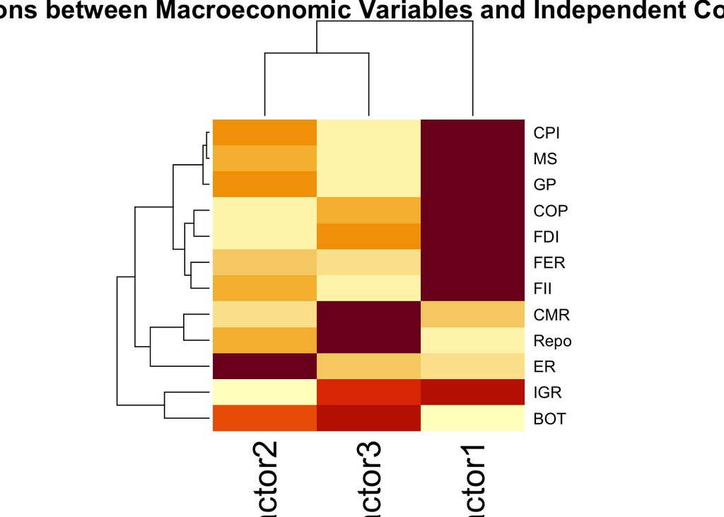

Figure

```r
heatmap(cor_factors, main="Correlations between Macroeconomic Variables and Independent Components")
```

Factor 1 (MR1) shows high positive loadings with variables such as Money Supply (MS), Consumer Price Index (CPI), Gold Prices (GP), Crude Oil Prices (COP), Foreign Exchange Reserves (FER), Foreign Direct Investment (FDI), and Foreign Institutional Investment (FII). These are key indicators of general economic activity, monetary policy, and inflation. Therefore, MR1 likely represents an economic growth and monetary supply factor, as it is heavily influenced by variables typically associated with overall economic activity and monetary conditions. Factor 2 (MR2) displays high positive values for Foreign Exchange Rate (ER) and negative values for Industrial Growth Rate (IGR) and Balance of Trade (BOT). This suggests that MR2 is a trade and currency factor, driven by fluctuations in exchange rates and trade balances, which are inversely related to industrial growth in this case. Factor 3 (MR3) has high positive loadings for Call Money Rate (CMR) and Repo Rate (Repo), both of which are key interest rates controlled by monetary authorities. Thus, MR3 appears to be a monetary policy factor, as it is strongly influenced by interest rate policies.